# Final_Project_A1093355彭郁庭

彭郁庭

2023-06-08

**研究動機**

**目的**:  
1.想了解新竹縣市近五年整體房價走勢  
2.統計分析房價和其他自變數的關係幫助制定決策

**資料表介紹** 內政部不動產成交案件實際資訊資料 (2018-2022)  
來源: 內政部  
介紹: 收集了民國101年至民國112年期間，包含不動產買賣、預售屋買賣、不動產租賃三種交易類別的房價實價登陸資料。每三個月為一季，  
一年共四季，可以匯出成XML、TXT、CSV或XLS格式檔案。利用進階下載可以選擇欲下載之縣市與交易類別。 本次研究蒐集了2018年至2022年新竹縣市的不動產買賣資料，共33個欄位，108503筆資料。

**本次報告將使用之欄位如下**:

- 鄉鎮市區
- 建物型態
- 主要用途
- 備註
- 交易年月日
- 建築完成年月
- 單價元平方公尺

來源網址:https://plvr.land.moi.gov.tw/DownloadOpenData

**欄位簡介**

| 欄位名稱 | 型態 | 簡介 |
| --- | --- | --- |
| 鄉鎮市區 | string | 新竹縣市鄉鎮市區名稱(共13區) |
| 建物型態 | string | 建物型態(共11種) |
| 主要用途 | string | 房屋的主要用途 |
| 備註 | string | 買賣備註 |
| 交易年月日 | string | 交易年月日(民國) |
| 建築完成年月 | string | 建築完成年月日(民國) |
| 單價元平方公尺 | double | 每平方公尺的價錢(元) |
| age | int | 從建築完成到交易完成時的屋齡 |
| year | string | 交易西元年 |
| price_per_ping | double | 每坪的價錢(元) |

**分析過程**  
**處理原始資料**:  
1. 新增屋齡、year、單價元坪欄位  
2. 留下交易年份為2018~2022的資料存入新的變數中  
3. 刪除單純車位買賣的交易紀錄  
4. 刪除有備註的交易紀錄(通常為不正常之交易)  
5. 只留下主要用途為住家用的交易紀錄  
6. 刪除單價元坪、屋齡欄位為空值的交易紀錄

```r
trade_initlist <- trade_initlist %>%
  mutate(age = as.integer(substring(交易年月日, 1, nchar(交易年月日) - 4)) - as.integer(substring(建築完成年月, 1, nchar(建築完成年月) - 4)))

trade_initlist <- trade_initlist %>%
  mutate(year = as.integer(substr(交易年月日, 1, nchar(交易年月日) - 4)) + 1911)

trade_initlist$單價元平方公尺 <- as.numeric(trade_initlist$單價元平方公尺)
trade_initlist$price_per_ping <- trade_initlist$單價元平方公尺 * 3.30579

trade_filtered <- trade_initlist %>%
  filter(year >= 2018 & year <= 2022)

trade_list <- trade_filtered %>%
  filter(交易標的 != "車位" & 主要用途 == "住家用" & grepl("^\\s*$", 備註) & !is.na(price_per_ping) & price_per_ping != 0 & !is.na(age))

trade_list <- trade_list %>%
  rename(district = 鄉鎮市區, sidearea = 附屬建物面積, type = 建物型態)
```

**敘述統計**:  
# 各地區資料分佈數量直方圖

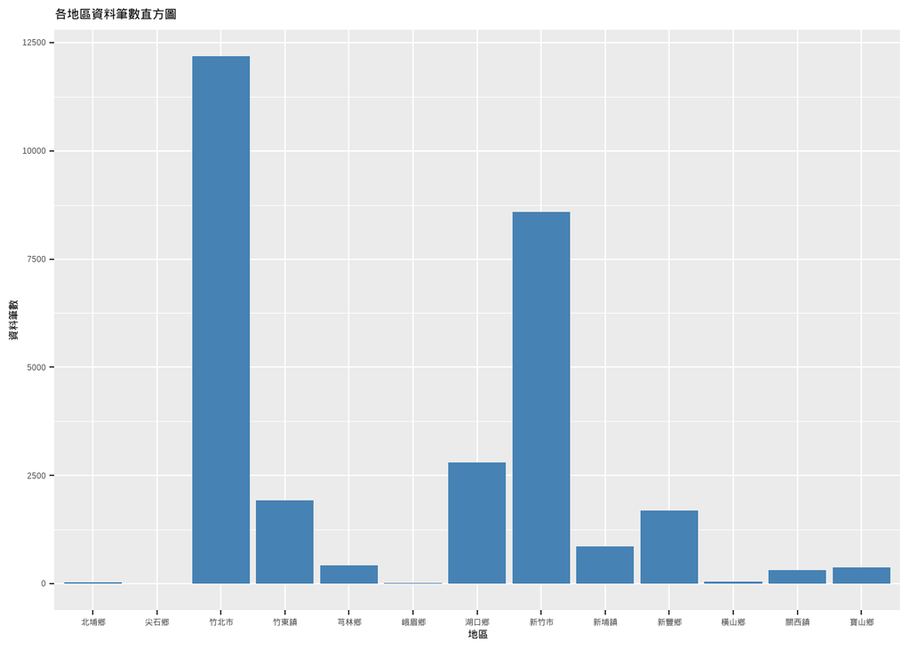

```r
district_counts <- table(trade_list$district)

district_counts_df <- data.frame(district = names(district_counts),
                                 count = as.numeric(district_counts))

district_counts_gg<- ggplot(data = district_counts_df, aes(x = district, y = count)) +
  geom_bar(stat = "identity", fill = "steelblue") +
  xlab("地區") +
  ylab("資料筆數") +
  ggtitle("各地區資料筆數直方圖")
district_counts_gg
```

# 各地區資料房價分佈盒狀圖

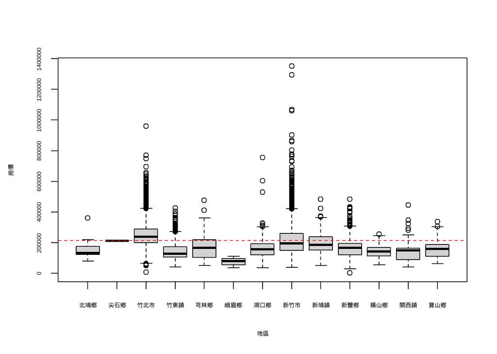

```r
district_sum <- Summarize(price_per_ping ~ district, data = trade_list)
age_sum <- Summarize(price_per_ping ~ age, data = trade_list)
type_sum <- Summarize(price_per_ping ~ type, data = trade_list)
boxplot(price_per_ping ~ district,
        data = trade_list,
        ylab="房價",
        xlab="地區",
        ylim = c(0, 1351139.2))
mean_value <- mean(trade_list$price_per_ping)
abline(h = mean_value, col = "red", lty = 2)
```

# 各地區對應單價元坪的直方圖

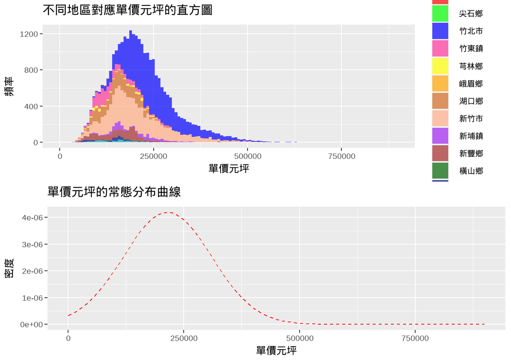

```r
district_colors <- c("red","green","blue","#FF359A","yellow","orange","chocolate","#FFAD86","purple","brown","darkgreen","darkblue","#00AEAE")
theme_set(theme(text = element_text(size = 20)))

histogram <- ggplot(data = trade_list, aes(x = price_per_ping, fill = district)) +
  geom_histogram(data = subset(trade_list, price_per_ping < 900000), bins = 120, alpha = 0.7) +
  xlim(0, 900000) +
  labs(fill = "district") +
  scale_fill_manual(values = district_colors) +
  xlab("單價元坪") +
  ylab("頻率") +
  ggtitle("不同地區對應單價元坪的直方圖")

mean_value <- mean(trade_list$price_per_ping)
sd_value <- sd(trade_list$price_per_ping)

# 繪製常態分佈曲線
density_curve <- ggplot(data = trade_list, aes(x = price_per_ping)) +
  stat_function(fun = dnorm, args = list(mean = mean_value, sd = sd_value), color = "red", linetype = "dashed") +
  xlim(0, 900000) +
  xlab("單價元坪") +
  ylab("密度") +
  ggtitle("單價元坪的常態分布曲線")

combined_plot <- cowplot::plot_grid(histogram, density_curve, nrow = 2, align = "v")
combined_plot
```

# 近五年各地區房價趨勢折線圖

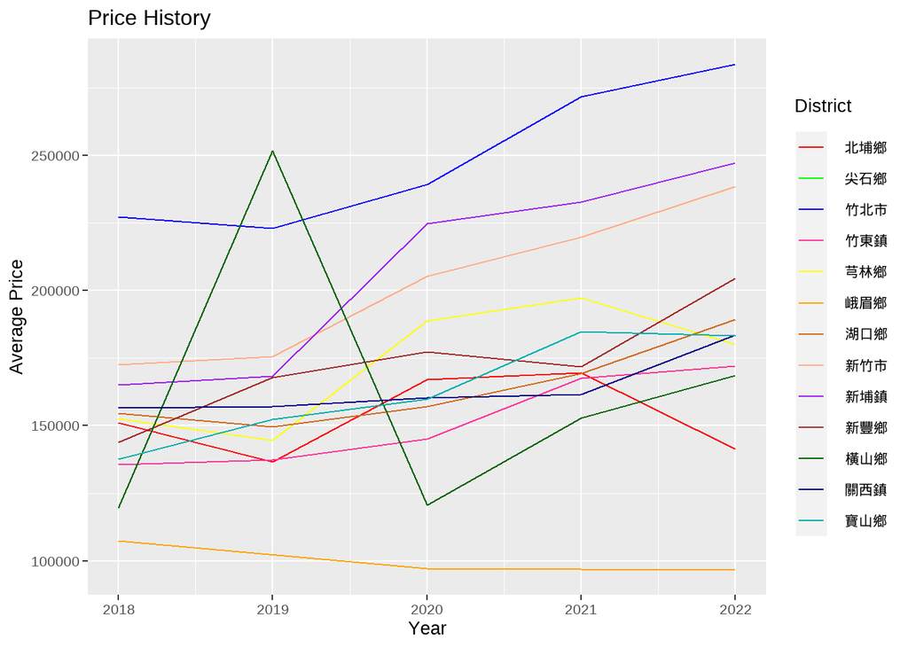

```r
districts <- unique(trade_list$`district`)
prices <- list()
for (district in districts) {
    cond <- (
        trade_list$`district` == district &
        trade_list$`price_per_ping` < quantile(trade_list$price_per_ping, 0.95) &
        trade_list$`price_per_ping` > quantile(trade_list$price_per_ping, 0.05)
        )
        groups <- trade_list$year[cond]

        prices[[district]] <- trade_list[cond, 'price_per_ping'] %>%
                            as.numeric() %>%
                            tibble(year = groups, price = .) %>%
                            group_by(year) %>%
                            summarise(mean_price = mean(price)) %>%
                            filter(year >= 2018) %>%
                            mutate(district = district)
}

price_history <- do.call(rbind, prices)
price_history <- price_history[order(price_history$year), ]

ggplot(price_history, aes(x = year, y = mean_price, color = district)) +
  geom_line() +
  labs(x = "Year", y = "Average Price", title = "Price History") +
  scale_color_manual(values = district_colors, name = "District")
```

# 新竹縣市總體房價趨勢圖

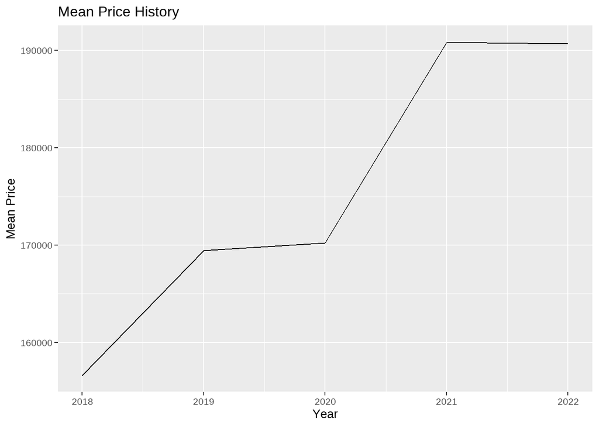

```r
price_history_mean <- aggregate(mean_price ~ year, data = price_history, FUN = mean)
ggplot(price_history_mean, aes(x = year, y = mean_price)) +
  geom_line() +
  labs(x = "Year", y = "Mean Price", title = "Mean Price History")
```

# “單價元坪”, “屋齡”, “附屬建物面積”變數QQ圖

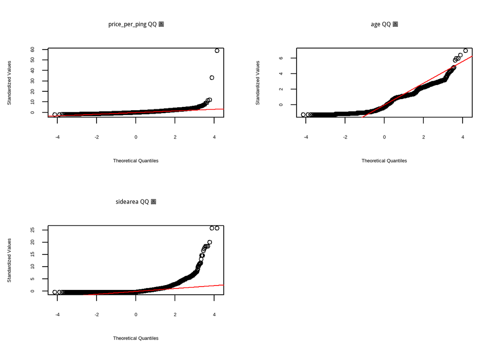

```r
par(mfrow = c(2, 2))
qq_plots <- lapply(c("price_per_ping", "age", "sidearea"), function(variable) {
  plot(qqnorm(scale(trade_list[[variable]]), plot.it = FALSE), xlab = "Theoretical Quantiles", ylab = "Standardized Values")
  qqline(scale(trade_list[[variable]]), col = "red")
  title(main = paste(variable, "QQ 圖"))
})
```

**統計分析房價和其他自變數的關係**:  
分析流程:  
1.將變數轉換為虛擬變數  
2.Create transactions  
3.Analyze the transactions  
# Association Rules

```r
trade_data <- data.frame()
trade_data <- trade_list %>%
  mutate(age = case_when(
    age < 10 ~ "0-9",
    age >= 10 & age < 20 ~ "10-19",
    age >= 20 & age < 30 ~ "20-29",
    TRUE ~ "30+"
  ))
trade_data <- trade_data %>%
  mutate(price = case_when(
    price_per_ping < 150000 ~ "低價位",
    price_per_ping > 150000 & price_per_ping < 230000 ~ "中價位",
    TRUE ~ "高價位"
  ))

trade_data <- trade_data[, c("district", "age","type", "price")]
district_filtered <- trade_data %>%
  filter(district == "竹北市" | district == "新竹市" | district == "新豐鄉"| district == "湖口鄉"| district == "竹東鎮")

research_list <- district_filtered %>%
  filter(type == "住宅大樓(11層含以上有電梯)" | type == "華廈(10層含以下有電梯)" | type == "透天厝")

district_dummy <- model.matrix(~ district - 1, data = research_list)
age_dummy <- model.matrix(~ age - 1, data = research_list)
building_dummy <- model.matrix(~ type - 1, data = research_list)
price_dummy <- model.matrix(~ price - 1, data = research_list)
data_dummy <- cbind(district_dummy, age_dummy, building_dummy, price_dummy)

trade_transactions <- transactions(data_dummy)

rules <- apriori(trade_transactions,
                 parameter = list(support = 0.005,
                                  confidence = 0.5,
                                  maxlen = 15,
                                  minlen =2,
                                  target = "rules")
)
```

```
## Apriori
##
## Parameter specification:
##  confidence minval smax arem  aval originalSupport maxtime support minlen
##         0.5    0.1    1 none FALSE            TRUE       5   0.005      2
##  maxlen target  ext
##      15  rules TRUE
##
## Algorithmic control:
##  filter tree heap memopt load sort verbose
##     0.1 TRUE TRUE  FALSE TRUE    2    TRUE
##
## Absolute minimum support count: 123
##
## set item appearances ...[0 item(s)] done [0.00s].
## set transactions ...[15 item(s), 24662 transaction(s)] done [0.00s].
## sorting and recoding items ... [15 item(s)] done [0.00s].
## creating transaction tree ... done [0.00s].
## checking subsets of size 1 2 3 4 done [0.00s].
## writing ... [205 rule(s)] done [0.00s].
## creating S4 object  ... done [0.00s].
```

```r
summary(rules)
```

```
## set of 205 rules
##
## rule length distribution (lhs + rhs):sizes
##  2  3  4
## 28 99 78
##
##    Min. 1st Qu.  Median    Mean 3rd Qu.    Max.
##   2.000   3.000   3.000   3.244   4.000   4.000
##
## summary of quality measures:
##     support           confidence        coverage             lift
##  Min.   :0.005028   Min.   :0.5000   Min.   :0.005231   Min.   :0.9197
##  1st Qu.:0.012408   1st Qu.:0.5667   1st Qu.:0.019504   1st Qu.:1.3755
##  Median :0.026559   Median :0.6475   Median :0.042454   Median :1.7695
##  Mean   :0.070096   Mean   :0.6760   Mean   :0.102254   Mean   :2.1601
##  3rd Qu.:0.070676   3rd Qu.:0.7715   3rd Qu.:0.118563   3rd Qu.:2.7067
##  Max.   :0.392263   Max.   :0.9935   Max.   :0.552388   Max.   :7.2393
##      count
##  Min.   : 124
##  1st Qu.: 306
##  Median : 655
##  Mean   :1729
##  3rd Qu.:1743
##  Max.   :9674
##
## mining info:
##                data ntransactions support confidence
##  trade_transactions         24662   0.005        0.5
##                                                                                                                                call
##  apriori(data = trade_transactions, parameter = list(support = 0.005, confidence = 0.5, maxlen = 15, minlen = 2, target = "rules"))
```

```r
plot(head(sort(rules,
               by = "lift"),
          n = 10),
     method = "graph",
     engine = "htmlwidget")
```

[interactive chart not shown]

# 查看高價位房價規則

```r
high_price_rules <- apriori(trade_transactions,
                 parameter = list(support = 0.005,
                                  confidence = 0.5,
                                  maxlen = 15,
                                  minlen =2),
                 appearance = list(rhs="price高價位")
)
```

```
## Apriori
##
## Parameter specification:
##  confidence minval smax arem  aval originalSupport maxtime support minlen
##         0.5    0.1    1 none FALSE            TRUE       5   0.005      2
##  maxlen target  ext
##      15  rules TRUE
##
## Algorithmic control:
##  filter tree heap memopt load sort verbose
##     0.1 TRUE TRUE  FALSE TRUE    2    TRUE
##
## Absolute minimum support count: 123
##
## set item appearances ...[1 item(s)] done [0.00s].
## set transactions ...[15 item(s), 24662 transaction(s)] done [0.00s].
## sorting and recoding items ... [15 item(s)] done [0.00s].
## creating transaction tree ... done [0.00s].
## checking subsets of size 1 2 3 4 done [0.00s].
## writing ... [15 rule(s)] done [0.00s].
## creating S4 object  ... done [0.00s].
```

```r
inspect(high_price_rules[1:5])
```

```
##     lhs                                                 rhs
## [1] {district竹北市}                                 => {price高價位}
## [2] {type住宅大樓(11層含以上有電梯)}                 => {price高價位}
## [3] {age0-9}                                         => {price高價位}
## [4] {district新竹市, type住宅大樓(11層含以上有電梯)} => {price高價位}
## [5] {district新竹市, age0-9}                         => {price高價位}
##     support    confidence coverage   lift     count
## [1] 0.27438975 0.5672730  0.48369962 1.396216 6767
## [2] 0.31096424 0.5749307  0.54087260 1.415064 7669
## [3] 0.30950450 0.5603024  0.55238829 1.379060 7633
## [4] 0.06224151 0.5249658  0.11856297 1.292086 1535
## [5] 0.06017355 0.7405190  0.08125862 1.822623 1484
```

```r
plot(head(sort(high_price_rules,
               by = "lift"),
          n = 10),
     method = "graph",
     engine = "htmlwidget")
```

[interactive chart not shown]